# Analisis de Correlacion Canonica (Fundamentos e Inferencia)

## Parte 1 - Fundamentos

## Objetivo

El **analisis de correlacion canonica** (`CCA`) es una tecnica estadistica que estudia la asociacion de dos conjuntos de variables simultaneamente observadas para el mismo conjunto de individuos o unidades de observacion

Usos de `CCA`:

1. Reduccion de dimensionalidad (explicando el comovimiento de dos variables en un conjunto de combinaciones lineales de dimensiones menores)
2. Exploracion de datos (mediante la creacion de `atributos latentes` o `variables canonicas` que explican el comovimiento de un conjunto de variables)

## Notacion

Suponemos \(X\) y \(Y\) dos conjuntos de variables de dimension \(p\) y \(q\) respectivamente, con

\[ X\sim N(\mu_x,\Sigma_x) \ \text{ y } \ Y\sim N(\mu_y,\Sigma_y) \] Si \(\Sigma_{xy}\) denota la covarianza entre \(X\) y \(Y\) entonces, \[ Z=(X,Y) \sim N(\mu,\Sigma), \] con \[\mu=(\mu_x,\mu_y)\] y \[ \Sigma = \left( \begin{array}[c c] \Sigma_{x} & \Sigma_{xy}\\ \Sigma_{yx} & \Sigma_{y}\end{array}\right). \]

## Combinaciones lineales

Para \(j=1,\ldots,r\), con \(r=\min(p,q)\), se definen las variables unidimensionales \[ u_j = <X,a_j>, \\ v_j = <Y,b_j>, \] para \(a_j\) y \(b_j\) vectores \(p\) y \(q\) dimensionales, respectivamente.

La **idea** es que estas nuevas variables \[U=(u_1,\ldots,u_r) \ \text{ y } \ V=(v_1,\ldots,v_r) \] resuman la correlacion implicita entre \(X\) y \(Y\) a traves de la especificacion cuidadosa de los *vectores de proyeccion* \((a_j,b_j)_{j=1}^{r}\).

## `CCA` definicion

Para \(j=1\) se eligen \(a_1\) y \(b_1\) tales que

1. \(corr(U_1,V_1)=\frac{a_1'\Sigma_{xy}b_1}{(a_1\Sigma_x a_1)^{1/2}(b_1\Sigma_y b_1)^{1/2}}\) sea *maxima*
2. sujeto a que \(var(U_1)\) y \(var(V_1)\) sean ambas unitarias.

Para \(j\geq 2\) se eligen \(a_j\) y \(b_j\) tales que

1. \(corr(U_j,V_j)=\frac{a_j'\Sigma_{xy}b_j}{(a_j\Sigma_x a_j)^{1/2}(b_j\Sigma_y b_j)^{1/2}}\) sea *maxima*
2. sujeto a que \(var(U_j)\) y\(var(V_j)\) sean ambas unitarias
3. \(corr\left((u_j,v_j),(u_l,v_l)\right)=0\) para todo \(l<j\).

**Nota: `CCA` es en esencia un problema de optimizacion cuadratica con restricciones.**

## `CCA` solucion matricial

Resulta ser que las \(j\)-esimas **variables canonicas** estan dadas por \[ U_j = e_{xj}'\Sigma_x^{-1/2}X \ \text{ y } \ V_j=e_{xj}'\Sigma_y^{-1/2} Y, \] donde \(e_{xj}\) y \(e_{yj}\) son vectores \(p\) y \(q\) dimensionales, respectivamente, que corresponden al \(j\)-esimo **eigenvector de las matrices**, \[ \Sigma_{x}^{-1/2}\Sigma_{xy}\Sigma_y^{-1}\Sigma_{yx}\Sigma_{x}^{-1/2}, \\ \Sigma_{y}^{-1/2}\Sigma_{yx}\Sigma_x^{-1}\Sigma_{xy}\Sigma_{y}^{-1/2}, \\ \] respectivamente.

**Nota:** El \(j\)-esimo eigenvector \(\rho_j\) de las matrices arriba corresponde con la **correlacion entre las variables canonicas** correspondientes, \(U_j\) y \(V_j\).

## `CCA` variables canonicas

Las nuevas **variables canonicas** se definen como \[ U = A'X \ \text{ y } \ V = B'Y, \] ambas de dimension \(r\), donde \[ A=(a_1',\ldots,a_r'),\\ B=(b_1',\ldots,b_r'), \] de dimensiones \((r\times p)\) y \((r\times q)\), respectivamente.

## Parte 2 - Implementacion

## Paquetes

### *Loading*

Cargamos los paquetes que usaremos en estas ilustraciones.

```
if (require(ggplot2) == FALSE){
  install.packages("ggplot2")
}
library("ggplot2")

if (require(GGally) == FALSE){
  install.packages("GGally")
}
library("GGally")

if (require(CCA) == FALSE){
  install.packages("CCA")
}
library("CCA")
```

## Datos

Los datos que analizamos corresponden a 600 registros de estudiantes relacionados con sus habilidades academicas, capacidades emocionales y actitud.

- **actitud** - `control`, `concepto`, `motivacion`
- **habiliades** - `lectura`, `escritura`, `matematicas`, `ciencias`
- **intrinsecas** - `genero`

### Objetivo

Resumir como estas variables en bloque se relacionan entre si.

## Datos

```r
datos <- read.csv("est46114_ccadata.csv", header = TRUE)
colnames(datos)
```

```
## [1] "control"     "concepto"    "motivacion"  "lectura"     "escritura"
## [6] "matematicas" "ciencia"     "genero"
```

```r
head(datos)
```

```
##   control concepto motivacion lectura escritura matematicas ciencia genero
## 1   -0.84    -0.24       1.00    54.8      64.5        44.5    52.6      1
## 2   -0.38    -0.47       0.67    62.7      43.7        44.7    52.6      1
## 3    0.89     0.59       0.67    60.6      56.7        70.5    58.0      0
## 4    0.71     0.28       0.67    62.7      56.7        54.7    58.0      0
## 5   -0.64     0.03       1.00    41.6      46.3        38.4    36.3      1
## 6    1.11     0.90       0.33    62.7      64.5        61.4    58.0      1
```

```r
dim(datos)
```

```
## [1] 600   8
```

## Datos

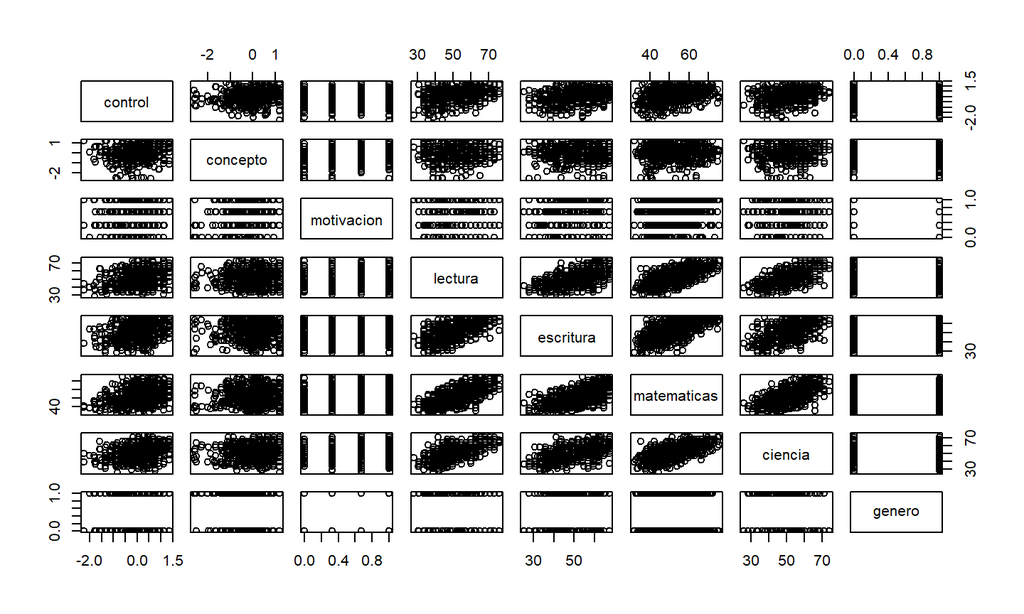

```r
plot(datos)
```

## Datos

Considerando el conjunto de `datos`, se requiere especificar dos conjuntos de variables. En este ejemplo, dividiremos en dos bloques:

1. `aptitud`+/-`genero`

```r
aptitud <- datos[,c("control","concepto","motivacion" )]
summary(aptitud)
```

```
##     control            concepto           motivacion
##  Min.   :-2.23000   Min.   :-2.620000   Min.   :0.0000
##  1st Qu.:-0.37250   1st Qu.:-0.300000   1st Qu.:0.3300
##  Median : 0.21000   Median : 0.030000   Median :0.6700
##  Mean   : 0.09653   Mean   : 0.004917   Mean   :0.6608
##  3rd Qu.: 0.51000   3rd Qu.: 0.440000   3rd Qu.:1.0000
##  Max.   : 1.36000   Max.   : 1.190000   Max.   :1.0000
```

## Datos

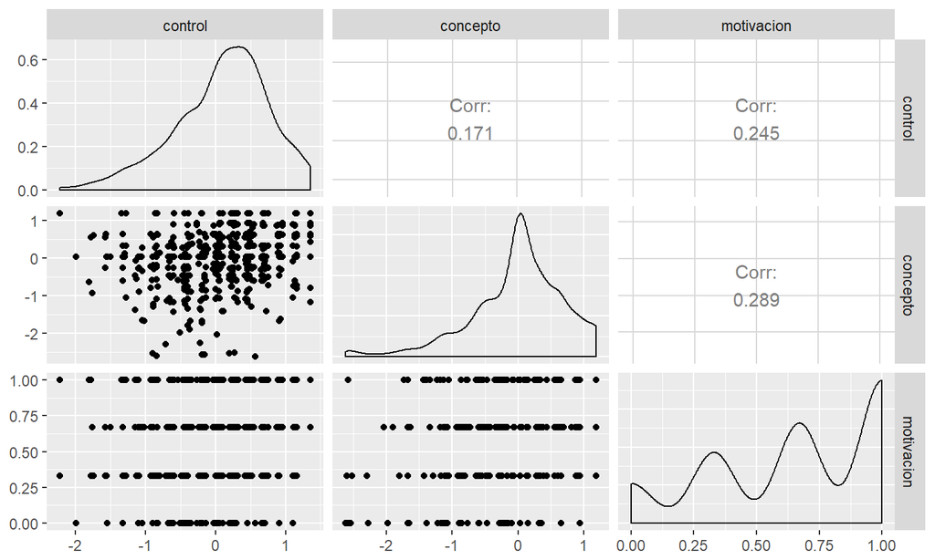

```r
ggpairs(aptitud)
```

## Datos

Considerando el conjunto de `datos`, se requiere especificar dos conjuntos de variables. En este ejemplo, dividiremos en dos bloques:

1. `habilidades`

```r
habilidades <- datos[,c("lectura","escritura","matematicas","ciencia")]
summary(habilidades)
```

```
##     lectura       escritura      matematicas       ciencia
##  Min.   :28.3   Min.   :25.50   Min.   :31.80   Min.   :26.00
##  1st Qu.:44.2   1st Qu.:44.30   1st Qu.:44.50   1st Qu.:44.40
##  Median :52.1   Median :54.10   Median :51.30   Median :52.60
##  Mean   :51.9   Mean   :52.38   Mean   :51.85   Mean   :51.76
##  3rd Qu.:60.1   3rd Qu.:59.90   3rd Qu.:58.38   3rd Qu.:58.65
##  Max.   :76.0   Max.   :67.10   Max.   :75.50   Max.   :74.20
```

## Datos

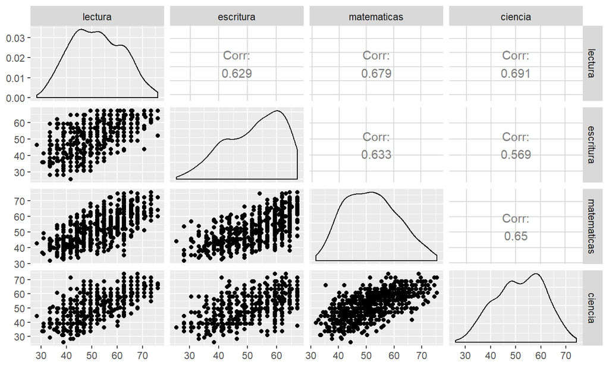

```r
ggpairs(habilidades)
```

## Datos

```r
mat.corr <- matcor(aptitud, habilidades)
```

1. **Aptitud**

```
##              control  concepto motivacion
## control    1.0000000 0.1711878  0.2451323
## concepto   0.1711878 1.0000000  0.2885707
## motivacion 0.2451323 0.2885707  1.0000000
```

1. **Habilidades**

```
##               lectura escritura matematicas   ciencia
## lectura     1.0000000 0.6285909   0.6792757 0.6906929
## escritura   0.6285909 1.0000000   0.6326664 0.5691498
## matematicas 0.6792757 0.6326664   1.0000000 0.6495261
## ciencia     0.6906929 0.5691498   0.6495261 1.0000000
```

## Datos

- **Aptitud** + **Habilidades**

```
##               control   concepto motivacion    lectura  escritura
## control     1.0000000 0.17118778  0.2451323 0.37356505 0.35887684
## concepto    0.1711878 1.00000000  0.2885707 0.06065584 0.01944856
## motivacion  0.2451323 0.28857075  1.0000000 0.21060992 0.25424818
## lectura     0.3735650 0.06065584  0.2106099 1.00000000 0.62859089
## escritura   0.3588768 0.01944856  0.2542482 0.62859089 1.00000000
## matematicas 0.3372690 0.05359770  0.1950135 0.67927568 0.63266640
## ciencia     0.3246269 0.06982633  0.1156695 0.69069291 0.56914983
##             matematicas    ciencia
## control       0.3372690 0.32462694
## concepto      0.0535977 0.06982633
## motivacion    0.1950135 0.11566948
## lectura       0.6792757 0.69069291
## escritura     0.6326664 0.56914983
## matematicas   1.0000000 0.64952612
## ciencia       0.6495261 1.00000000
```

## `CCA` analisis

```r
datos.cc <- cc(aptitud, habilidades)
```

*Nota: Revisen la documentacion de la funcion `cc` y la libreria `CCA` en general.*

```r
summary(datos.cc)
```

```
##        Length Class  Mode
## cor     3     -none- numeric
## names   3     -none- list
## xcoef   9     -none- numeric
## ycoef  12     -none- numeric
## scores  6     -none- list
```

**Correlacion canonica**

Hasta `3` coeficientes de correlacion canonica… *Recuerdan?*

```r
datos.cc$cor
```

```
## [1] 0.44643648 0.15335902 0.02250348
```

## `CCA` analisis

**Coeficientes `CCA`**

- **aptitud**

```
##                  [,1]       [,2]       [,3]
## control    -1.2501212  0.7659633  0.4966529
## concepto    0.2367331  0.8421110 -1.2051225
## motivacion -1.2491434 -2.6359625 -1.0935085
```

- **habilidades**

```
##                     [,1]        [,2]        [,3]
## lectura     -0.044047131 -0.00159291 -0.08833171
## escritura   -0.055088843 -0.09041460  0.09612884
## matematicas -0.019401098 -0.00295546 -0.08782244
## ciencia      0.003797762  0.12420898  0.08849519
```

*Como interpretamos estas cifras???*

## `CCA` analisis

**Loadings `CCA`**

```r
datos.cc.coef <- comput(aptitud, habilidades, datos.cc)
summary(datos.cc.coef)
```

```
##                Length Class  Mode
## xscores        1800   -none- numeric
## yscores        1800   -none- numeric
## corr.X.xscores    9   -none- numeric
## corr.Y.xscores   12   -none- numeric
## corr.X.yscores    9   -none- numeric
## corr.Y.yscores   12   -none- numeric
```

Los datos en este apartado corresponden a las *correlaciones* entre las *variables originales* y las *variables canonicas*.

## `CCA` analisis

**Loadings `CCA`**

- **aptitud**

```
##                   [,1]       [,2]        [,3]
## control    -0.91428518  0.3936580  0.09547756
## concepto   -0.09996773  0.4213083 -0.90139104
## motivacion -0.58532551 -0.6061228 -0.53852502
```

```
##                   [,1]        [,2]         [,3]
## lectura     -0.3930571  0.03755922 -0.006144737
## escritura   -0.4063141 -0.03388766  0.007646605
## matematicas -0.3571452  0.02882125 -0.006381333
## ciencia     -0.3098729  0.10365354  0.005348465
```

## `CCA` analisis

**Loadings `CCA`**

- **aptitud**

```
##                   [,1]        [,2]         [,3]
## control    -0.40817026  0.06037101  0.002148577
## concepto   -0.04462924  0.06461142 -0.020284434
## motivacion -0.26131066 -0.09295440 -0.012118686
```

```
##                   [,1]       [,2]       [,3]
## lectura     -0.8804322  0.2449104 -0.2730572
## escritura   -0.9101273 -0.2209695  0.3397966
## matematicas -0.7999910  0.1879332 -0.2835709
## ciencia     -0.6941031  0.6758881  0.2376728
```

## `CCA` analisis

**Significacia del `CCA`**

*Las dimensiones canonicas ( o variables canonicas), son variables latentes que son analogas a los factores obtenidos en el `AF`.*

**P:** Cuales de esas variables canonicas son estadisticamente significativas???

```r
pv <- pf(f, d1, d2, lower.tail = FALSE)
dmat <- cbind(WilksL = w, F = f, df1 = d1, df2 = d2, p = pv)
dmat
```

```
##         WilksL         F df1      df2            p
## [1,] 0.7814670 12.773540  12 1569.222 2.630211e-25
## [2,] 0.9759865  2.421026   6 1188.000 2.487710e-02
## [3,] 0.9994936       NaN   2      NaN          NaN
```

## `CCA` analisis

**Significacia del `CCA`**

- Ajustes por variaciones en escala en los datos originales.

**Aptitud** La matriz diagonal de coeficientes canÃ³nicos estandarizados de `aptitud` dada por sd.

```r
s1 <- diag(sqrt(diag(cov(aptitud))))
s1 %*% datos.cc$xcoef
```

```
##            [,1]       [,2]       [,3]
## [1,] -0.8379311  0.5134098  0.3328964
## [2,]  0.1670182  0.5941199 -0.8502290
## [3,] -0.4281181 -0.9034217 -0.3747775
```

## `CCA` analisis

**Significacia del `CCA`**

**Habilidades** La matriz diagonal estandarizada de los coeficientes `habiliades` academicas con base en sd.

```r
s2 <- diag(sqrt(diag(cov(habilidades))))
s2 %*% datos.cc$ycoef
```

```
##             [,1]        [,2]       [,3]
## [1,] -0.44500741 -0.01609314 -0.8924138
## [2,] -0.53581915 -0.87941356  0.9349929
## [3,] -0.18265622 -0.02782487 -0.8268251
## [4,]  0.03686176  1.20559459  0.8589501
```

## `CCA` temas avanzados

- Implicaciones de emplear variables `estandarizadas` o `no estandarizadas`
- Implicaciones de realizar `CCA` con variables discretas o categoricas
- Incorporacion de la **incertidumbre epistemica** asociada con el aprendizaje de \(\Sigma_x\), \(\Sigma_y\) y \(\Sigma_{xy}\) **especialmente**, como en el caso de `PCA`
- Anticipar/predecir la **correlacion canonica** entre un conjunto de variables futuras \(x^{f}\) y \(y^{f}\), con base en el aprendizaje realizado
- *Escalabilidad* de la solucion
- `CCA` para mas de dos conjuntos de variables simultaneamente
- `CCA` no lineal o no parametrico